# Monte Carlo Blackjack

Karanpreet Benipal

# 1. Objective

The goal of this project is to use Monte Carlo Simulation to evaluate and compare different blackjack strategies, focusing on both how players choose to act (hit, stand, split, etc.) and how they place their bets. By simulating thousands of games we estimate the expected return per dollar bet. The focus is on the math and not on the nuances of Blackjack.  
I have no personal interest in Blackjack and as such I am using a standard set of rules for Blackjack using what seemed to be the most common variation for each particular rule. If for some reason you are reading this because you are interested in gambling and not math (hard to imagine), you should be aware that the exact results calculated here may not be applicable in your particular scenario.

# 2. What is Monte Carlo Simulation?

### 2.1 Basics

Monte Carlo (MC) Simulation involves randomly simulating some process and then taking a measurement of that process. This is done repeatedly. We can then use the results to understand the process. The goal being to estimate some quantity, let’s call it $\mu$. Let X be the result of a single simulation run and g(X) be a function of the result such that $\mathbb{E}(g(X))=\mu$. The MC estimate after n-many runs is denoted $\hat{\mu}_n^{mc}$.

### 2.2 In the Context of Blackjack

Let’s understand this in the context of Blackjack. We are interested in knowing how much we can expect to win or lose for each strategy of interest. For each game we simulate we want to divide the payout by the bet put in.  
Formulated as above:

- For the i-th simulation where $i\in[1,n]$
- $X_i = \{payout_i,\ bet\ in_i\}$
- $g(X_i) = \frac{payout_i}{bet\ in_i}$
- $\hat{\mu}_n^{mc}=\frac{1}{n}\Sigma^n_{i=1}g(X_i)$

### 2.3 Confidence Intervals (CI)

We want to quantify the uncertainty around our MC estimate. To do so we can use one of two types of confidence intervals:

- The empirical CI which involves taking sample quantiles from the simulated results.
- The asymptotic CI which is derived from the Central Limit Theorem.

For our purposes we will use the asymptotic CI which assumes that for a large enough n the sample mean is normally distributed with mean $\mu$ and variance as defined below.

Let $S^2_n = \frac{1}{n-1} \sum_{i=1}^n (g(X_i) - \hat{\mu}_n^{mc})^2$ be the sample variance, this is an estimate of the true variance, $Var(g(X))=\sigma^2$.

The variance of the MC estimator (denoted $\tilde{\mu}_n^{mc}$) is can be derived as follows:

$$\begin{align*}
\text{Var}(\tilde{\mu}_n^{mc}) &= \text{Var}\left(\frac{1}{n}
\sum_{i=1}^n g(X_i)\right) \\
&= \frac{1}{n^2} \sum_{i=1}^n \text{Var}(g(X_i)) \\
&= \frac{1}{n^2} \sum_{i=1}^n \sigma^2 \quad \text{since } g(X_i)
\text{ are i.i.d.} \\
&= \frac{\sigma^2}{n} \\
&\approx \frac{S_n^2}{n} \quad \text{using the sample variance}
\end{align*}$$

Denote the $1-\frac{\alpha}2$ normal quantile (also called a critical value in the context of CI) as $Z_{1-\frac{\alpha}2}$.

Then the $(1-\alpha)\%$ confidence interval is:
$$I_{\alpha,n}=\hat{\mu}_n^{mc}\pm
Z_{1-\frac{\alpha}2}\times \frac{\sigma}{\sqrt n}$$
Which we approximate with:
$$I_{\alpha,n}=\hat{\mu}_n^{mc}\pm
Z_{1-\frac{\alpha}2}\times \frac{S_n}{\sqrt n}$$

### 2.4 Pilot Runs

How many simulation runs do we need to get accurate results? We can choose what level of precision we require and then insure we do enough simulation runs. This is where using the asymptotic CI is beneficial. Consider we want the confidence interval on either side of the estiamte to be no larger than $\varepsilon$.
That is we want:
$$Z_{1-\frac{\alpha}2}\times \frac{S_n}{\sqrt
n} <\varepsilon$$
We can rearrange this to get:
$$Z_{1-\frac{\alpha}2}\times
\frac{S_n}{\varepsilon} <\sqrt n$$
$$Z_{1-\frac{\alpha}2}^2\times
\frac{S_n^2}{\varepsilon^2} <n$$

Now we can calculate how many simulation runs we need in order to reach a desired level of precision. Of course, we need $S_n$ in order to do this. We can estimate it by first doing a small pilot study, typically of about 50 or 100 runs to estimate $S_n$. Then we simply plug that into the inequality to get the minimum number of runs needed.

# 3. The Rules of Blackjack

There is no one set of rules for Blackjack, there are all sort of different variations that different casinos and counties tend to use. The rules I am using are based on the Bicycle cards’ webpage about Blackjack found [here](https://bicyclecards.com/how-to-play/blackjack).

Each player is playing against the dealer (or house). The objective of the game is to have the total of your cards be higher than that of the dealer’s while also remaining at of below 21. An ace can be counted as a 1 or 11, a Jack, Queen and King are all counted as 10s. Every other card is counted as it’s face value (i.e. 8 is 8, 2 is 2, etc).

The game proceeds as follows:

- The dealer gives each player two cards face-up and themselves one card face up and one face down.
- If the the dealer’s upcard is a ten of an ace they check their face down card to see if they have a natural (opening total of 21). If so the dealer wins, unless the player also has a natural, and vice-versa for the player.
- The player can take the following actions:
  - Surrender: give up half the bet and forfeit the hand.
  - Split: If the player’s two cards are identical they can split the hand into two hands that are settled separately. The player must add a bet equal to the original to each hand. So if the initial bet was $\$100$, the player must now bet $\$100$ on each hand for a total of $\$200$.
  - Stand: End the hand.
  - Double Down: if the total is a 9, 10, or 11 the player can double the bet and get just one more card.
  - Hit: player receives one more card and then can continue there turn.
- If a player’s hand goes over 21 that player loses and they pay their bet immediately regardless of what happens in the dealer’s turn.
- Once every player has had their turn the dealer plays.
- The dealer reveals their face down card and then hits until they reach 17.
- If a player still in the game has a total higher than the dealer’s or the dealer busts (goes over 21) that player wins.
- If the dealer and player have the same total it is a tie (called a ‘push’ in Blackjack).
- One game of Blackjack consists of playing multiple rounds like this until some portion of the deck has been dealt.

Rules used for our Purposes:

- Dealer hits on soft 17. A soft 17 is a 17 with an ace involved such that the hand total could be 7 or 17.
- 6 standard 52 card decks are used. Bottom 35% is not dealt. Multiple decks and not dealing every card is standard practice to deter card counters.
- Player can split 4 times.
- Players can double down after a split.
- Blackjack pays 1.5 times the bet (put in $\$100$, get back $\$250$)

# 4. Game Functions

The following functions pertain to the running of the game loop. They are included here for interest. An understanding of these functions is not needed to understand the results or the concepts of Monte Carlo Simulation.

**Click to show code.**

```r
# Create the deck
create_deck <- function(num_decks = 1) {
  ranks <- c(2:10, "J", "Q", "K", "A")
  deck <- rep(ranks, times = 4 * num_decks)
  return(sample(deck))  # shuffle
}
```

```r
# Get card value
card_value <- function(cards) {
  values <- sapply(cards, function(card) {
    if (card %in% c("J", "Q", "K")) return(10)
    if (card == "A") return(11)
    return(as.numeric(card))
  })

  # Adjust for Aces
  while (sum(values) > 21 && 11 %in% values) {
    idx <- which(values == 11)[1]
    values[idx] <- 1
  }

  return(sum(values))
}

# Check for soft hand
is_soft_hand <- function(hand) {
  total <- card_value(hand)
  has_ace <- "A" %in% hand
  hand <- sapply(hand, function(x) if(x %in% c("J", "Q", "K")) 10 else x)
  total_with_ace_as_one <- sum(sapply(hand, function(x) if(x == "A") 1 else as.numeric(x)))
  return(has_ace && total - total_with_ace_as_one == 10)
}
```

```r
# Dealer hits until 17
# H17 = TRUE means "hit on soft 17", otherwise dealer stands on soft 17
# A 'soft 17' is a hand with an ace such that it could be a 7 or 17
dealer_play <- function(deck, dealer_hand, H17 = TRUE) {

  while (card_value(dealer_hand) < 17 || H17 && is_soft_hand(dealer_hand) && card_value(dealer_hand) == 17) {
    dealer_hand <- c(dealer_hand, deck[1])
    deck <- deck[-1]
  }
  return(list(hand = dealer_hand, deck = deck))
}
```

```r
# play one round
play_blackjack <- function(deck, cards_seen, player_play, placed_bet, player_count = NULL, max_splits = 4) {

  # get bet
  bet <- placed_bet

  # Initial deal
  player_hand <- deck[1:2]
  dealer_hand <- deck[3:4]
  deck <- deck[-(1:4)]

  # insurance, there is only one insurance case so I will just hard code it for convenience
  ins_bet <- 0
  ins_pay <- 0
  # only Ill18 uses insurance
  if(dealer_hand[1] == "A" && identical(player_play, player_ill18_strat)) {
    # check idx
    if(player_count(c(player_hand, dealer_hand[1], cards_seen), length(deck) / 52) >= 3) {
      # take insurance
      ins_bet <- 0.5 * bet

      if(dealer_hand[2] %in% c(10, "J", "Q", "K")) {
        # insurance win
        ins_pay <- bet # pays double of ins_bet
      }
    }
  }


  # Check for player natural
  if (card_value(player_hand) == 21) {
    # update counting
    cards_seen <- c(cards_seen, player_hand, dealer_hand)
    if (card_value(dealer_hand) == 21) {
      return(list(deck = deck, cards_seen = cards_seen, payout = bet+ins_pay, bet = bet+ins_bet))
    } else {
      return(list(deck = deck, cards_seen = cards_seen, payout = 2.5*bet+ins_pay, bet = bet+ins_bet))
    }
  }

  # Dealer natural
  if (card_value(dealer_hand) == 21) {
    cards_seen <- c(cards_seen, player_hand, dealer_hand)
    return(list(deck = deck, cards_seen = cards_seen, payout = ins_pay, bet = bet+ins_bet))
  }

  # Player turn
  # Call function differently depending on whether or not we are counting cards
  if(!is.null(player_count)) { # player is card counting
    # cards seen + dealer's upcard used for the count
    # decks left = number of cards left divided by 52
    curr_count <- player_count(c(cards_seen, dealer_hand[1]), length(deck) / 52)
    result <- player_play(deck, list(player_hand), dealer_hand[1], count = curr_count, split_count = 0, max_splits = max_splits)
  } else {
    result <- player_play(deck, list(player_hand), dealer_hand[1], split_count = 0, max_splits = max_splits)
  }

  player_hands <- result$hands
  deck <- result$deck
  dds <- result$dds  # double down flags per hand
  num_hands <- length(player_hands)

  # Check for surrender
  if(result$surrender) {
    cards_seen <- c(cards_seen, player_hand, dealer_hand) # no new cards since surrendered
    return(list(deck = deck, cards_seen = cards_seen, payout = 0.5*bet+ins_pay, bet = bet+ins_bet))
  }

  # Dealer turn
  result <- dealer_play(deck, dealer_hand)
  dealer_hand <- result$hand
  deck <- result$deck
  dealer_score <- card_value(dealer_hand)

  # record dealer hand
  cards_seen <- c(cards_seen, dealer_hand)

  # Evaluate each hand
  total_bet <- bet * (num_hands + sum(dds)) # what player put in
  payout <- total_bet # what player gets once all hands are resolved

  for (i in seq_along(player_hands)) {
    hand <- player_hands[[i]]
    dd <- dds[i]
    this_bet <- bet * ifelse(dd == 1, 2, 1)
    player_score <- card_value(hand)

    if (player_score > 21) {
      payout <- payout - this_bet
    } else if (dealer_score > 21 || player_score > dealer_score) {
      payout <- payout + this_bet
    } else if (player_score < dealer_score) {
      payout <- payout - this_bet
    } # else push: no change

    # update cards seen
    cards_seen <- c(cards_seen, hand)
  }

  # return deck, cards seen, money in and money out
  return(list(deck = deck, cards_seen = cards_seen, payout = payout+ins_pay, bet = total_bet+ins_bet))
}
```

# 5. Simulation Functions

These functions run the simulation itself.  
The ‘simulate_blackjack’ function runs n-many games of blackjack and records the return per dollar bet. It can write the full results to a csv file or return the mean ($\mu_n$) and variance ($S_n^2$) of the sample of size n.

Where $\mu_n$ is the Monte Carlo Estimate and $S_n^2$ is the sample variance which is an estimate of the variance $\sigma^2$, which can be used to calculate the variance of the Monte Carlo Estimator.

**Click to show code.**

```r
## Monte Carlo Simulation
## Simulate n-many games of Blackjack. 1 game involves dealing the entire deck
## up-to the 'cut' card. Here the cut card is placed such that the bottom 35%
## of the deck is not dealt This is standard practice to make things more
## difficult for card counters.
## The result of one game is the money made divided by the money put it.
## The simulation thus seeks to estimate the expected return per dollar bet
## for the given strategies.
simulate_blackjack <- function(n = 1000, num_decks = 6, player_strat, player_bet = function(d,r) 1, player_count = NULL, output_file = NULL) {

  res <- numeric(length = n)

  # when to stop the round, don't deal bottom 35% of cards
  cut <- 0.35 * num_decks * 52

  for (i in 1:n) {
    deck <- create_deck(num_decks)
    total_bet <- 0
    payout <- 0
    cards_seen <- c()
    # if the cut hasn't been hit play another hand
    while(cut < length(deck)) {
      # play a hand
      d_left <- length(deck) / 52
      bet <- player_bet(cards_seen, d_left)
      hand_res <- play_blackjack(deck, cards_seen, player_strat, bet, player_count = player_count)

      deck <- hand_res$deck
      cards_seen <- hand_res$cards_seen
      payout <- payout + hand_res$payout
      total_bet <- total_bet + hand_res$bet
    }

    res[i] <- payout / total_bet
  }

  # store results
  results_df <- data.frame(game = 1:n, result = res)

  # output
  if(is.null(output_file)) {
    list(mu = mean(results_df$res), S_n2 = var(results_df$res))
  } else {
    write.csv(results_df, file = output_file, row.names = FALSE)
  }
}
```

The ‘run_simulations’ function calls the ‘simulate_blackjack’ function for a various number of decks and returns or records the results.

```r
# Final simulations
# Code to run simulations for a variable number of decks
run_simulations <- function(num_decks = c(1), runs=c(1), player_strat, player_bet = function(d,r) 1, player_count = NULL, output_file=NULL) {

  # to store results
  l <- length(num_decks)
  results_df <- data.frame(decks = num_decks,
                           n = runs,
                           mu = numeric(length = l),
                           mu_var = numeric(length = l))

  # Run simulation for each number of decks
  for(i in 1:l) {
    res <- simulate_blackjack(n = runs[i], num_decks = num_decks[i], player_strat, player_bet, player_count)
    results_df$mu[i] <- res$mu
    results_df$mu_var[i] <- res$S_n2 / runs[i] # Variance of MC estimator
  }

  # return or write the output
  if(is.null(output_file)) {
    results_df
  } else {
    write.csv(results_df, file = output_file, row.names = FALSE)
  }
}
```

# 6. Playing Strategy

The following subsections contain the the strategies and functions used by the player to decide how to play the game.

### 6.1 Beginner Player

This “strategy” involves hitting until a value of 17 is reached, just like the dealer plays.

**Click to show code.**

```r
player_no_strat <- function(deck, player_hand, upcard, split_count, max_splits=4) {
  # player_hand is a list with just one element
  hand <- player_hand[[1]]

  # Hit till 17
  while (card_value(hand) < 17) {
    hand <- c(hand, deck[1])
    deck <- deck[-1]
  }

  # Make sure hand is returned as a list, dds a vector
  return(list(hands = list(hand), deck = deck, dds=c(0), surrender=FALSE))
}
```

### 6.2 Intermediate Player

This strategy uses the playing strategy outlined on the Bicycle Card’s page on how to play Blackjack, found [here](https://bicyclecards.com/how-to-play/blackjack). The strategy here is simple and does not involve muchS memorization.

**Click to show code.**

```r
player_bi_strat <- function(deck, player_hands, upcard, split_count, max_splits=4) {

  final_hands <- list()
  final_dds <- c()

  # Play each hand
  for(hand in player_hands) {

    # Is player allowed to split this hand
    can_split <- (length(hand) == 2 && hand[1] == hand[2] && split_count < max_splits)

    # Is splitting in accordance with the strategy
    should_split <- (hand[1] %in% c("A", 8) || upcard %in% 2:7 && hand[1] %in% c(2,3,7) || hand[1] == 6 && upcard %in% 2:6)

    # Either split the hand or play it
    if(can_split && should_split) {

      # Split the pair into two hands
      card_to_split <- hand[1]

      hand1 <- c(card_to_split, deck[1])
      deck <- deck[-1]

      hand2 <- c(card_to_split, deck[1])
      deck <- deck[-1]


      # Recursively play both split hands
      res1 <- player_bi_strat(deck, list(hand1), upcard, split_count + 1, max_splits)
      res2 <- player_bi_strat(res1$deck, list(hand2), upcard, split_count + 1, max_splits)

      final_hands <- c(final_hands, res1$hands, res2$hands)
      final_dds <- c(final_dds, res1$dds, res2$dds)
      deck <- res2$deck
    } else {

      # Doubling Down
      val <- card_value(hand)
      if(val == 11 || val == 10 && upcard %in% c(10, "J", "Q", "K", "A") || val == 9 && upcard %in% 2:6) {
        # draw just one more card

        hand <- c(hand, deck[1])
        deck <- deck[-1]

        # store hand results and go to next hand
        final_hands <- c(final_hands, list(hand))
        final_dds <- c(final_dds, 1)
        next
      }

      # Play normally without doubling down
      # pick target based on upcard
      target <- ifelse(upcard %in% c(2, 3), 13,
                       ifelse(upcard %in% c(4, 5, 6), 12, 17))

      # Soft hand strategy
      if("A" %in% hand) { target <- 18 }

      # Draw until target is reached
      while (card_value(hand) < target) {
        hand <- c(hand, deck[1])
        deck <- deck[-1]
      }

      # store hand results and go to next hand
      final_hands <- c(final_hands, list(hand))
      final_dds <- c(final_dds, 0)
      next
    }
  }

  # return list of hands, double-down flags, and deck
  return(list(hands = final_hands, deck = deck, dds = final_dds, surrender=FALSE))
}
```

### 6.3 Advanced Player: Basic Strategy

This strategy uses what is called “basic strategy”. This involves uses a chart which lists what plays to make given every possible combination of player hand and the dealer’s upcard. The charts used are found [here](https://www.blackjackapprenticeship.com/wp-content/uploads/2024/09/H17-Basic-Strategy.pdf).

**Click to show code.**

```r
# Basic strategy chart for hard total
dealer_upcards <- c(2:10, "A")

hard_total_chart <- matrix(c(
# Dealer Upcard
#  2   3   4   5   6   7   8   9  10   A
  "H","H","H","H","H","H","H","H","H","H",  # 8 Player Total
  "H","D","D","D","D","H","H","H","H","H",  # 9
  "D","D","D","D","D","D","D","D","H","H",  #10
  "D","D","D","D","D","D","D","D","D","D",  #11
  "H","H","H","H","H","H","H","H","H","H",  #12
  "S","S","S","S","S","H","H","H","H","H",  #13
  "S","S","S","S","S","H","H","H","H","H",  #14
  "S","S","S","S","S","H","H","H","H","H",  #15
  "S","S","S","S","S","H","H","H","H","H",  #16
  "S","S","S","S","S","S","S","S","S","S"   #17
), nrow = 10, byrow = TRUE)

# Add row and column names
rownames(hard_total_chart) <- as.character(8:17)
colnames(hard_total_chart) <- as.character(dealer_upcards)

# Basic strategy chart for soft total

soft_total_chart <- matrix(c(
# Dealer Upcard
#  2    3    4    5    6    7    8    9   10    A
  "S", "S", "S", "S", "S", "S", "S", "S", "S", "S",   # A,9 i.e 20
  "S", "S", "S", "S", "Ds","S", "S", "S", "S", "S",   # A,8
  "Ds","Ds","Ds","Ds","Ds","S", "S", "H", "H", "H",   # A,7
  "H", "D", "D", "D", "D", "H", "H", "H", "H", "H",   # A,6
  "H", "H", "D", "D", "D", "H", "H", "H", "H", "H",   # A,5
  "H", "H", "D", "D", "D", "H", "H", "H", "H", "H",   # A,4
  "H", "H", "H", "D", "D", "H", "H", "H", "H", "H",   # A,3
  "H", "H", "H", "D", "D", "H", "H", "H", "H", "H"    # A,2 i.e 13
), nrow = 8, byrow = TRUE)

# Add row and column names
rownames(soft_total_chart) <- as.character(20:13)
colnames(soft_total_chart) <- as.character(dealer_upcards)

# Splitting chart

pair_split_chart <- matrix(c(
# Dealer Upcard
#   2     3     4     5     6     7     8     9    10     A
  TRUE, TRUE, TRUE, TRUE, TRUE, TRUE, TRUE, TRUE, TRUE, TRUE,            # A,A
  FALSE, FALSE, FALSE, FALSE, FALSE, FALSE, FALSE, FALSE, FALSE, FALSE,  # T,T: 10, J, Q, or K
  TRUE, TRUE, TRUE, TRUE, TRUE, FALSE, TRUE, TRUE, FALSE, FALSE,         # 9,9
  TRUE, TRUE, TRUE, TRUE, TRUE, TRUE, TRUE, TRUE, TRUE, TRUE,           # 8,8
  TRUE, TRUE, TRUE, TRUE, TRUE, FALSE, FALSE, FALSE, FALSE, FALSE,      # 7,7
  TRUE, TRUE, TRUE, TRUE, TRUE, FALSE, FALSE, FALSE, FALSE, FALSE,      # 6,6
  FALSE, FALSE, FALSE, FALSE, FALSE, FALSE, FALSE, FALSE, FALSE, FALSE,  # 5,5
  FALSE, FALSE, FALSE, TRUE,  TRUE,  FALSE, FALSE, FALSE, FALSE, FALSE,  # 4,4
  TRUE, TRUE, TRUE, TRUE,  TRUE,  TRUE,  FALSE, FALSE, FALSE, FALSE,    # 3,3
  TRUE, TRUE, TRUE, TRUE,  TRUE,  FALSE, FALSE, FALSE, FALSE, FALSE     # 2,2
), nrow = 10, byrow = TRUE)

# Add row and column names
rownames(pair_split_chart) <- c("A", "T", "9", "8", "7", "6", "5", "4", "3", "2")
colnames(pair_split_chart) <- as.character(dealer_upcards)
```

```r
# Define Basic strat function

get_action <- function(soft_hand, val, upcard) {
  if(soft_hand) {
    if(val == 21) {
      action <- "S" # stand
    } else if(val == 12) {
      action <- "H"
    } else {
      action <- soft_total_chart[as.character(val) , as.character(upcard)]
    }

  } else {
    if(val > 17) {
      action <- "S"
    } else if (val < 8) {
      action <- "H"
    } else {
      action <- hard_total_chart[as.character(val) , as.character(upcard)]
    }
  }
  # return action
  action
}

player_basic_strat <- function(deck, player_hands, upcard, split_count, max_splits=4) {

  final_hands <- list()
  final_dds <- c()

  # Surrender?

  if(split_count == 0) { # can only surrender at the very start
    # Surrender condition
    if(card_value(player_hands[[1]]) == 16 && upcard %in% c(9, 10, "J", "Q", "K", "A") ||
       card_value(player_hands[[1]]) == 15 && upcard %in% c(10, "J", "Q", "K")) {

      return(list(hands = list(player_hands), deck = deck, dds = c(0), surrender=TRUE))
    }
  }


  # Simplify upcard by changing 10, J, Q, K into 10
  upcard <- ifelse(upcard %in% c("J", "Q", "K"), 10, upcard)

  # Play each hand
  for(hand in player_hands) {

    # Is player allowed to split this hand
    can_split <- (length(hand) == 2 && hand[1] == hand[2] && split_count < max_splits)

    # Is splitting in accordance with the strategy
    player_card <- ifelse(hand[1] %in% c(10, "J", "Q", "K"), "T", hand[1])
    should_split <- pair_split_chart[as.character(player_card), as.character(upcard)]

    # Either split the hand or play it
    if(can_split && should_split) {
      # Split the pair into two hands
      card_to_split <- hand[1]
      hand1 <- c(card_to_split, deck[1])
      deck <- deck[-1]
      hand2 <- c(card_to_split, deck[1])
      deck <- deck[-1]

      # Recursively play both split hands
      res1 <- player_basic_strat(deck, list(hand1), upcard, split_count + 1, max_splits)
      res2 <- player_basic_strat(res1$deck, list(hand2), upcard, split_count + 1, max_splits)

      final_hands <- c(final_hands, res1$hands, res2$hands)
      final_dds <- c(final_dds, res1$dds, res2$dds)
      deck <- res2$deck
    } else {

      # Check the charts to see what we do initially
      action <- get_action(is_soft_hand(hand), card_value(hand), upcard)

      # Doubling Down
      if(action == "D") {
        # draw just one more card

        hand <- c(hand, deck[1])
        deck <- deck[-1]

        # store hand results and go to next hand
        final_hands <- c(final_hands, list(hand))
        final_dds <- c(final_dds, 1)
        next
      }

      # Play normally without doubling down
      # Hit until we stand
      while (action != "S") {
        hand <- c(hand, deck[1])
        deck <- deck[-1]
        # update action
        action <- get_action(is_soft_hand(hand), card_value(hand), upcard)
      }

      # store hand results and go to next hand
      final_hands <- c(final_hands, list(hand))
      final_dds <- c(final_dds, 0)
      next
    }
  }

  # return list of hands, double-down flags, and deck and surrender flag
  return(list(hands = final_hands, deck = deck, dds = final_dds, surrender=FALSE))
}
```

### 6.4 Expert: Card Counting Deviations

Card counting deviations involves playing with the basic strategy, however deviating from the basic strategy if the count is high enough in certain situations. The counting schemes and deviations and detailed below. The counting strategies and deviations are found [here](https://wizardofodds.com/games/blackjack/card-counting/high-low/).

#### 6.4.1 Counting Schemes: Hi-lo and Omega II

Card counting involves keeping a running count based on the cards seen so far. Each card has a value assigned to it, when you see a card you add the corresponding value to your running count.

The first is Hi-Lo counting which assigns values as follows:

| Card Rank | Count Value |
| --- | --- |
| 2 | +1 |
| 3 | +1 |
| 4 | +1 |
| 5 | +1 |
| 6 | +1 |
| 7 | 0 |
| 8 | 0 |
| 9 | 0 |
| 10 | –1 |
| J | –1 |
| Q | –1 |
| K | –1 |
| A | –1 |

**Click to show code.**

```r
hi_lo_count <- function(cards, decks_left) {
  count <- 0
  for(i in seq_along(cards)) {
    if(cards[i] %in% 2:6) {
      count <- count + 1
    } else if( !(cards[i] %in% 7:9)) {
      count <- count - 1
    }
  }
  # return true count
  count / decks_left
}
```

The next is Omega II which assigns values as follows:

| Card Rank | Count Value |
| --- | --- |
| 2 | +1 |
| 3 | +1 |
| 4 | +2 |
| 5 | +2 |
| 6 | +2 |
| 7 | +1 |
| 8 | 0 |
| 9 | –1 |
| 10 | –2 |
| J | –2 |
| Q | –2 |
| K | –2 |
| A | 0 |

**Click to show code.**

```r
omega_ii_count <- function(cards, decks_left) {
  count <- 0
  for(i in seq_along(cards)) {
    if(cards[i] %in% c(2,3,7)) {
      count <- count + 1
    } else if(cards[i] %in% 4:6) {
      count <- count + 2
    } else if(cards[i] == -9) {
      count <- count - 1
    } else if(cards[i] %in% c(10, "J", "Q", "K")) {
      count <- count - 2
    }
  } # 8 or A, count <- count + 0
  # return true count
  count / decks_left
}
```

#### 6.4.2 The Illustrious 18 and Fab 4

There are many card counting deviations. The ones used here are the Illustrious 18 and Fab 4. Ill 18 provides 17 situations in which one should stand/double/split if the true count exceeds or matches the provided ‘index number’, otherwise one should hit; and one situation in which one should take insurance. The Fab 4 provides four situations in which one should surrender.

**Click to show code.**

```r
# Illustrious 18 table as a data frame
illustrious_18 <- data.frame(
  player = c("I", "16", "15", "10,10", "10,10", "10", "12", "12", "11", "9",
             "10", "9", "16", "13", "12", "12", "12", "13"),
  upcard = c("I", "10", "10", "5", "6", "10", "3", "2", "A", "2",
             "A", "7", "9", "2", "4", "5", "6", "3"),
  index = c(3, 0, 4, 5, 4, 4, 2, 3, 1, 1,
            4, 3, 5, -1, 0, -2, -1, -2),
  stringsAsFactors = FALSE
)

# This function returns the required index to make an index play given
# the player hand value and the upcard. If the situation does not
# match an Illustrious 18 situation then return NULL
find_illustrious_index <- function(player_val, upcard_val) {
  row_match <- which(illustrious_18$player == as.character(player_val) &
                       illustrious_18$upcard == as.character(upcard_val))
  if (length(row_match) == 0) {
    return(NULL)
  } else {
    return(illustrious_18$index[row_match])
  }
}

# Fab 4 Surrenders as a data frame
fab4_surrenders <- data.frame(
  player = c("14", "15", "15", "15"),
  upcard = c("10", "10", "9", "A"),
  index = c(3, 0, 2, 1),
  stringsAsFactors = FALSE
)

# This function returns the required index to surrender. If the situation
# does not match a Fab 4 situation then return NULL
find_surrender_index <- function(player_val, upcard_val) {
  row_match <- which(fab4_surrenders$player == as.character(player_val) &
                       fab4_surrenders$upcard == as.character(upcard_val))
  if (length(row_match) == 0) {
    return(NULL)
  } else {
    return(fab4_surrenders$index[row_match])
  }
}

# This function gets the action for the ill 18 plays, it uses the previous
# get action function
get_action_ill18 <- function(soft_hand, val, upcard, count) {
  # check for index play
  play_idx <- find_illustrious_index(val, upcard)

  if(!is.null(play_idx) && count >= play_idx) { # index play
    # double if possible otherwise stand
    # if you can double down then that is the action to take
    if(val %in% 9:11 || val %in% 16:18 && soft_hand) {
      action <- "D"
    } else {
      # otherwise we stand
      action <- "S"
    }
  } else { # regular play
    # Check the charts
    action <- get_action(soft_hand, val, upcard)
  }
  action
}

# Basic strat modified to included ill 18 and fab 4 deviations
player_ill18_strat <- function(deck, player_hands, upcard, count, split_count, max_splits=4) {

  final_hands <- list()
  final_dds <- c()

  # Simplify upcard by changing 10, J, Q, K into 10
  upcard <- ifelse(upcard %in% c("J", "Q", "K"), 10, upcard)

  #### Surrender? ####
  if(split_count == 0) { # can only surrender at the very start
    # Surrender conditions
    # Basic strategy surrender
    surrender <- card_value(player_hands[[1]]) == 16 && upcard %in% c(9, 10, "J", "Q", "K", "A") ||
      card_value(player_hands[[1]]) == 15 && upcard %in% c(10, "J", "Q", "K")

    # Index play using fab 4 surrenders
    fab4_idx <- find_surrender_index(card_value(player_hands[[1]]), upcard)

    if(!is.null(fab4_idx) && count >= fab4_idx) {
      surrender <- TRUE
    }

    if(surrender) {
      return(list(hands = list(player_hands), deck = deck, dds = c(0), surrender=TRUE))
    }
  }

  #### Play each hand ####
  for(hand in player_hands) {

    # Is player allowed to split this hand
    can_split <- (length(hand) == 2 && hand[1] == hand[2] && split_count < max_splits)

    # Is splitting in accordance with the strategy
    player_card <- ifelse(hand[1] %in% c(10, "J", "Q", "K"), "T", hand[1])
    should_split <- pair_split_chart[as.character(player_card), as.character(upcard)]

    # check index splits
    if(player_card == "T") {
      split_idx <- find_illustrious_index("10,10", upcard_val = upcard)

      if(!is.null(split_idx) && count >= split_idx) {
        should_split <- TRUE
      }
    }

    # Either split the hand or play it
    if(can_split && should_split) {

      # Split the pair into two hands
      card_to_split <- hand[1]
      hand1 <- c(card_to_split, deck[1])
      deck <- deck[-1]
      hand2 <- c(card_to_split, deck[1])
      deck <- deck[-1]

      # Recursively play both split hands
      res1 <- player_ill18_strat(deck, list(hand1), upcard, count, split_count + 1, max_splits)
      res2 <- player_ill18_strat(res1$deck, list(hand2), upcard, count, split_count + 1, max_splits)

      final_hands <- c(final_hands, res1$hands, res2$hands)
      final_dds <- c(final_dds, res1$dds, res2$dds)
      deck <- res2$deck
    } else {
      #### Don't split; play the hand ####
      ## initial move
      action <- get_action_ill18(is_soft_hand(hand), card_value(hand), upcard, count)

      # Doubling Down
      if(action == "D" || action == "Ds") {
        # draw just one more card

        hand <- c(hand, deck[1])
        deck <- deck[-1]

        # store hand results and go to next hand
        final_hands <- c(final_hands, list(hand))
        final_dds <- c(final_dds, 1)
        next
      }

      #### Play normally without doubling down ####
      # Hit until we stand
      while (action != "S") {
        hand <- c(hand, deck[1])
        deck <- deck[-1]
        # update action
        action <- get_action_ill18(is_soft_hand(hand), card_value(hand), upcard, count)

        # Ds = double if allowed otherwise stand, too late to double so we stand
        if(action == "Ds") {
          action <- "S"
        }
      }

      # store hand results and go to next hand
      final_hands <- c(final_hands, list(hand))
      final_dds <- c(final_dds, 0)
      next
    }
  }

  # return list of hands, double-down flags, and deck and surrender flag
  return(list(hands = final_hands, deck = deck, dds = final_dds, surrender=FALSE))
}
```

# 7. Betting Strategy

Betting strategy involves changing your bet based on the ‘true count’ which is determined by some counting scheme and the number of decks left in the game. In general, smaller cards result in increasing the count and larger cards result in decreasing the count. A higher true count means the cards left are likely to be larger, a lower count means the cards are likely to be lower. Here we implement the Hi-Lo and Omega II counting schemes.

### 7.1 Hi-Lo and Omega II Bets

```r
hi_lo_bet <- function(cards, decks_left) {
  true_count <- hi_lo_count(cards, decks_left)

  if (true_count >= 5) {
    return(10)
  } else if (true_count >= 3) {
    return(5)
  } else if (true_count >= 1) {
    return(2)
  } else {
    return(1)
  }
}

omega_ii_bet <- function(cards, decks_left) {
  true_count <- omega_ii_count(cards, decks_left)

  if (true_count >= 4) {
    return(10)
  } else if (true_count >= 2) {
    return(5)
  } else {
    return(1)
  }
}
```

# 8. Results

### 8.1 Expected Return for 6 Deck Games

The following code creates a table outlining the expected return for each combination of strategies discussed above along with a 95% confidence interval based on the normal distribution. We can use this code to get the estimates of $S_n^2$, and then again for the final runs to get our results.

**Click to show code.**

```r
# Creates one row for the display table, with 95% CI
create_row <- function(n, play_lab="p", bet_lab="b", play=player_no_strat, bet=function(d,r) 1, count=NULL, d=6) {

  res <- simulate_blackjack(n, d, play, bet, count)
  mu <- res$mu
  S_n2 <- res$S_n2

  Z <- qnorm(0.975)
  se <- sqrt(S_n2 / n) # Standard Error

  data.frame(
    Play = play_lab,
    Bet = bet_lab,
    Expected_Return = mu,
    S_n2 = S_n2,
    CI_lwr = mu - Z * se,
    CI_upr = mu + Z * se
  )
}

# Creates the display table for n runs
create_table <- function(n, decks=6) {
  res_table <- rbind(
  # No strat runs
  create_row(n, "Hit to 17", "Bet 1", player_no_strat, d=decks),
  create_row(n, "Hit to 17", "Hi-Lo", player_no_strat, hi_lo_bet, d=decks),
  create_row(n, "Hit to 17", "Omega II", player_no_strat, omega_ii_bet, d=decks),

  # Bicycle strat runs
  create_row(n, "Bicycle", "Bet 1", player_bi_strat, d=decks),
  create_row(n, "Bicycle", "Hi-Lo", player_bi_strat, hi_lo_bet, d=decks),
  create_row(n, "Bicycle", "Omega II", player_bi_strat, omega_ii_bet, d=decks),

  # Basic strat runs
  create_row(n, "Basic", "Bet 1", player_basic_strat, d=decks),
  create_row(n, "Basic", "Hi-Lo", player_basic_strat, hi_lo_bet, d=decks),
  create_row(n, "Basic", "Omega II", player_basic_strat, omega_ii_bet, d=decks),

  # Ill 18 + fab 4 runs, using same counting method for betting and player, and no bet + hilo count plays
  create_row(n, "Ill18", "Bet 1", player_ill18_strat, count = hi_lo_count, d=decks),
  create_row(n, "Ill18", "Hi-Lo", player_ill18_strat, hi_lo_bet, hi_lo_count, d=decks),
  create_row(n, "Ill18", "Omega II", player_ill18_strat, omega_ii_bet, omega_ii_count, d=decks)
  )
  # print in descending order and with corrected row numbers
  res_table <- res_table[order(-res_table$Expected_Return),]
  rownames(res_table) <- 1:12
  res_table
}
```

#### 8.1.1 Pilot Runs

```r
pilot_table <- create_table(n = 125)
max_var <- pilot_table$S_n2[which.max(pilot_table$S_n2)]
max_var
```

```
## [1] 0.04477078
```

Let’s choose $\varepsilon=0.003$ & $\alpha=0.05$, plugging this into our formula from before we have:

$$\begin{align*}
Z_{1-\frac{\alpha}2}^2\times \frac{S_n^2}{\varepsilon^2} &< n \\
Z_{1-\frac{0.05}2}^2\times \frac{0.04477078}{0.003^2} &< n \\
19109.45671 &< n \\
\end{align*}$$

Based on this we can choose n = 19,110 as the number of simulations to run.

#### 8.1.2 True Runs

```r
create_table(n = 19110)
```

```
##         Play      Bet Expected_Return       S_n2    CI_lwr    CI_upr
## 1      Ill18    Hi-Lo       1.0005891 0.03077856 0.9981018 1.0030765
## 2      Basic    Hi-Lo       0.9987038 0.03123684 0.9961979 1.0012096
## 3      Basic Omega II       0.9971837 0.04369619 0.9942199 1.0001474
## 4      Ill18    Bet 1       0.9947319 0.02734710 0.9923873 0.9970765
## 5      Ill18 Omega II       0.9917691 0.04157429 0.9888782 0.9946599
## 6      Basic    Bet 1       0.9912128 0.02651994 0.9889039 0.9935216
## 7    Bicycle    Hi-Lo       0.9898220 0.03273945 0.9872566 0.9923874
## 8    Bicycle Omega II       0.9879338 0.04510932 0.9849225 0.9909450
## 9    Bicycle    Bet 1       0.9842928 0.02736023 0.9819476 0.9866380
## 10 Hit to 17    Hi-Lo       0.9404408 0.03194662 0.9379067 0.9429750
## 11 Hit to 17    Bet 1       0.9368617 0.02665192 0.9345471 0.9391763
## 12 Hit to 17 Omega II       0.9363848 0.04437915 0.9333980 0.9393716
```

We see that only three strategies have 1 within the 95% confidence interval. It is worth noting that the expected returns for the top 6, which are Ill18 and Basic with each of three betting strategies, are very similar. The results reflect what I found online when looking at Blackjack strategy - that is to first learn Basic strategy, and then the Ill18 deviations. From the table we can see that Hi-Lo counting generally performs better than the more complex Omega II scheme. When researching for this I found Hi-Lo was synonymous with card counting and only found one mention of Omega II. I though this was because Hi-Lo was easier but not necessarily better, these results seem to suggest Hi-Lo is not only simpler, but the better card counting scheme.

### 8.2 Expected Return as a Function of Decks in Play

For interest we can see how each strategy fares when the number of decks in play increases. A higher number of decks is expected to deter card counting strategies, we can see to what degree this is true.

#### 8.2.1 Pilot Runs

Firstly, we should consider that when increasing or decreasing the number of decks the sample variance may change. When more decks are in a game, that game goes on longer and involves more hands, thus more bets. This may result in a lower variance, as we are in a sense doing more simulation.

```r
# Common number of decks, except for 16 which is meant to see if card counting fails
num_decks <- c(1,2,4,6,8,16)

max_vars <- numeric(length = 6)

for(d in 1:6) {
  pt <- create_table(n = 150, decks = num_decks[d])
  max_vars[d] <- pt$S_n2[which.max(pt$S_n2)]
}

data.frame(decks = num_decks, max_S_n2 = max_vars)
```

```
##   decks   max_S_n2
## 1     1 0.24706239
## 2     2 0.14401401
## 3     4 0.07637211
## 4     6 0.05297473
## 5     8 0.03345620
## 6    16 0.01936119
```

We can see that our hypothesis was correct! The variance does decrease as the number of decks in play increases. The time it takes to run the simulation also increases with a larger number of decks so having less runs of the longer simulations should help with computing time. We can find the needed number of runs as before. Let’s use $\alpha=0.05$ as before and a looser precision of $\varepsilon=0.005$ .

```r
Z <- qnorm(0.975)
epsilon <- 0.005
runs <- ceiling(max_vars * (Z/epsilon)^2)
data.frame(decks = num_decks,
           n = runs)
```

```
##   decks     n
## 1     1 37964
## 2     2 22129
## 3     4 11736
## 4     6  8141
## 5     8  5141
## 6    16  2976
```

#### 8.2.2 Results

With everything set we can now run the simulations. The code below uses the run_simulations function with the number of runs we calculated above for each number of decks.

**Click to show code.**

```r
# No strat runs
run_simulations(num_decks, runs, player_strat=player_no_strat, output_file="no_no.csv")
run_simulations(num_decks, runs, player_no_strat, hi_lo_bet, output_file="no_hilo.csv")
run_simulations(num_decks, runs, player_no_strat, omega_ii_bet, output_file = "no_omega.csv")

# Bicycle strat runs
run_simulations(num_decks, runs, player_bi_strat, output_file = "bi_no.csv")
run_simulations(num_decks, runs, player_bi_strat, hi_lo_bet, output_file = "bi_hilo.csv")
run_simulations(num_decks, runs, player_bi_strat, omega_ii_bet, output_file = "bi_omega.csv")

# Basic strat runs
run_simulations(num_decks, runs, player_basic_strat, output_file = "bas_no.csv")
run_simulations(num_decks, runs, player_basic_strat, hi_lo_bet, output_file = "bas_hilo.csv")
run_simulations(num_decks, runs, player_basic_strat, omega_ii_bet, output_file = "bas_omega.csv")

# Ill 18 + fab 4 runs, using same counting method for betting and player, and no bet + hilo count plays
run_simulations(num_decks, runs, player_ill18_strat, player_count = hi_lo_count, output_file = "ill18_no.csv")
run_simulations(num_decks, runs, player_ill18_strat, hi_lo_bet, hi_lo_count,  output_file = "ill18_hilo.csv")
run_simulations(num_decks, runs, player_ill18_strat,omega_ii_bet, omega_ii_count,output_file = "ill18_omega.csv")
```

The following code creates the graph. Each line represents a combination of betting and playing strategy. The y-axis is the expected return, the x-axis is the number of decks in play.

**Click to show code.**

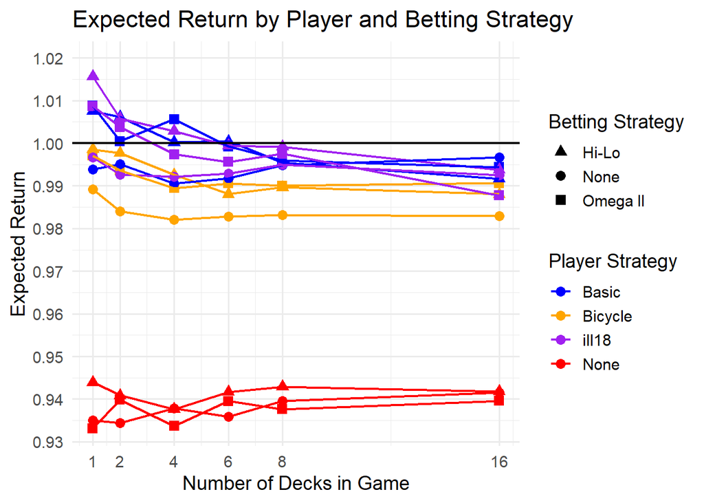

```r
# Add player and betting strategy columns
no_no     <- no_no    %>% mutate(player_strategy = "None",  betting_strategy = "None")
no_hilo   <- no_hilo  %>% mutate(player_strategy = "None",  betting_strategy = "Hi-Lo")
no_omega  <- no_omega %>% mutate(player_strategy = "None",  betting_strategy = "Omega II")
bi_no     <- bi_no    %>% mutate(player_strategy = "Bicycle", betting_strategy = "None")
bi_hilo   <- bi_hilo  %>% mutate(player_strategy = "Bicycle", betting_strategy = "Hi-Lo")
bi_omega  <- bi_omega %>% mutate(player_strategy = "Bicycle", betting_strategy = "Omega II")

bas_no     <- bas_no    %>% mutate(player_strategy = "Basic", betting_strategy = "None")
bas_hilo   <- bas_hilo  %>% mutate(player_strategy = "Basic", betting_strategy = "Hi-Lo")
bas_omega  <- bas_omega %>% mutate(player_strategy = "Basic", betting_strategy = "Omega II")

ill18_no     <- ill18_no    %>% mutate(player_strategy = "ill18", betting_strategy = "None")
ill18_hilo   <- ill18_hilo  %>% mutate(player_strategy = "ill18", betting_strategy = "Hi-Lo")
ill18_omega  <- ill18_omega %>% mutate(player_strategy = "ill18", betting_strategy = "Omega II")

# Combine all of them
combined_df <- bind_rows(no_no, no_hilo, no_omega, bi_no, bi_hilo, bi_omega,
                         bas_no, bas_hilo, bas_omega, ill18_no, ill18_hilo, ill18_omega)


colors <- c("None" = "red", "Bicycle" = "orange", "Basic" = "blue", "ill18" = "purple")
color_labels <- c("None" = "None", "Bicycle" = "Bicycle", "Basic" = "Basic", "ill18" = "ill18")

shapes <- c("None" = 16, "Hi-Lo" = 17, "Omega II" = 15)
shape_labels <- c("None" = "None", "Hi-Lo" = "Hi-Lo", "Omega II" = "Omega II")

# Plot
ggplot(combined_df, aes(x = decks, y = mu)) +
  geom_point(aes(color = player_strategy, shape = betting_strategy), size = 3) +
  geom_line(aes(group=interaction(player_strategy, betting_strategy), color=player_strategy), linewidth=0.75) +
  geom_hline(yintercept = 1, color = "black", linetype = "solid", linewidth = 0.8) +
  scale_color_manual(name = "Player Strategy", values = colors, labels = color_labels) +
  scale_shape_manual(name = "Betting Strategy", values = shapes, labels = shape_labels) +
  scale_x_continuous(breaks = c(1, 2, 4, 6, 8, 16)) +
  scale_y_continuous(
    breaks = scales::pretty_breaks(n = 12),
    expand = expansion(mult = c(0.05, 0.1))
  ) +
  theme_minimal(base_size = 14) +
  labs(
    title = "Expected Return by Player and Betting Strategy",
    x = "Number of Decks in Game",
    y = "Expected Return"
  )
```

# 9. Conclusion

So, what have we learned? Monte Carlo simulation is very fun, statistics is beautiful, and gambling is a bad idea. Unless, you are okay with losing money.  
I hope this was an interesting introduction to Monte Carlo. For further information on Monte Carlo simulation I would suggest reading about Variance Reduction Techniques (VRT), which are very important to simulation and are widely used particularly with stock market simulations; but were not applicable to the example of Blackjack.  
Thank you for reading.